Back to Portfolio

To Capstone Analysis

# D502 Capstone Report

*Project completed by Allysa Grace Fontillas for D502 Data Analytics Capstone | August 09, 2024*

- Introduction
- Dataset Overview and Summary
- Users - Key Findings
- Rides - Key Findings

### Introduction

In the following report, I present the key findings I've obtained from analyzing a Ford GoBike dataset. The goal of the project was to deliver Ford an in-depth analysis of their bike service data, providing them with meaningful insights to guide future business decisions.

The project addressed the following research question:

#### What are common characteristics of the consumer base and which variables are associated with demand at the top 10 starting stations?

The project focused on addressing Ford's organizational needs by extracting actionable insights from the dataset, which will help them implement targeted marketing strategies and meet demand effectively.

### Dataset Overview and Summary

The dataset used in this analysis contains information about individual rides from the Ford GoBike service in the San Francisco Bay Area. The cleaned dataset consists of 174,880 entries and 12 columns, covering rides that occurred from February 01, 2019 to March 01, 2019.

```python
#Imports the libraries I'll be using
import pandas as pd
import numpy as np
import matplotlib.pyplot as plt
import seaborn as sns
from scipy.stats import chisquare as cs
```

```python
#Loads in the clean datasets; one for general user population, other focuses on top 7 start stations
cleanData = pd.read_csv('clean201902_ford.csv')
startStations = pd.read_csv('startStations_fordgobike.csv')
freqSt = pd.read_csv('freqofStations.csv')
```

### Users - Key Findings

#### Users' Age Distribution by User Type

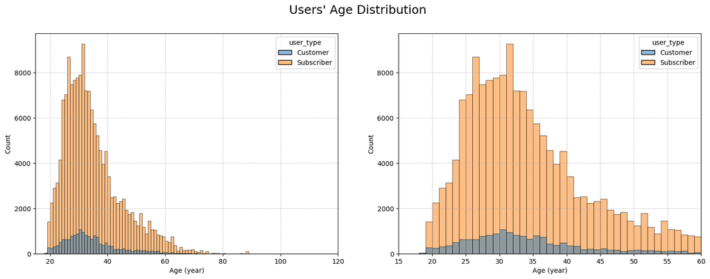

```python
#Setting up the figure for 2 plots side by side
plt.figure(figsize=[18,6])

#Histogram (on the left axis)
plt.subplot(1, 2, 1)
bins= np.arange(0, cleanData['user_age'].max()+1, 1)
sns.histplot(data=cleanData, x='user_age', hue='user_type', bins=bins);
plt.xlim(15,120);
plt.grid(True, linewidth='.5', linestyle='--')
plt.xlabel('Age (year)');

#Close up (on the right axis)
plt.subplot(1, 2, 2)
sns.histplot(data=cleanData, x='user_age', hue='user_type', bins=bins);
plt.xlim(15,60);
plt.grid(True, linewidth='.5', linestyle='--')
plt.xlabel('Age (year)');
plt.suptitle("Users' Age Distribution", fontsize=18);
```

The customer graph is unimodal. It has a slight rightward skew with a peak at approximately 30 years old.

Overall, the user minimum age is 18 and the maximum age is 99. From the graph, we can see that most users in Ford's GoBike system are around 23-40 years old and the majority of the users in the system are subscribers.

Action: A large amount of users are around 23-40 years old. Marketing campaigns can be tailored to this age group by focusing on their lifestyles and preferences. Marketing strategies should focus on features that appeal to this demographic such as convenience and fitness.

Emphasizing a focus on fitness and health may also attract clients of the older population. Ford BikeShare can further increase their appeal by emphasizing the benefits of convenience, such as users not having to pay for bike maintenance and storage in a congested city like San Francisco.

The majority of users are subscribers. Ford can attract new subscribers and retain existing subscribers by rewarding them with perks such as referral bonuses or free rides earned through a point system.

### Rides - Key Findings

#### Top 10 Start Stations and Times

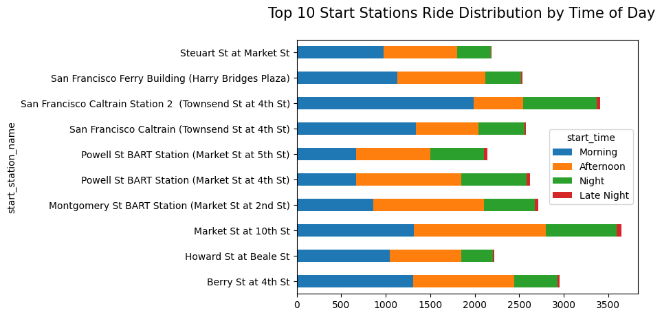

```python
#Arranges start_time into an ordered categorical type
dayTimes = ['Morning', 'Afternoon', 'Night', 'Late Night']
dtOrdered= pd.CategoricalDtype(ordered=True, categories=dayTimes)

#The warning for the line below does not appear to be correct. Even when I change it to the suggested syntax, a warning occurs.
#And when I change it to "startStations.loc['start_time'].astype(daysOrdered)" it will work initially,
#but it does not work when if I restart the kernel and run all cells
startStations['start_time'] = startStations['start_time'].astype(dtOrdered);

#Produces a crosstab or a contingency table to display the frequency distribution of start stations and start_times
ct_stationTimes = pd.crosstab(startStations['start_station_name'], startStations['start_time'])

#Horizontal Bar Chart of the contingency table
ct_stationTimes.plot.barh(stacked=True);
plt.suptitle("Top 10 Start Stations Ride Distribution by Time of Day", fontsize=15);
```

These are the top 10 start stations with the highest amount of bike rides. San Francisco Caltrain Station 2 and Market St at 10th St are the most popular start stations among Ford BikeShare users. Powell St BART Station has the lowest amount of rides.

In general, most bike rides begin in the morning (*5AM-11AM*) and afternoon (*12PM-5PM*).

*Notice* most of these stations are located at a transportation system such as BART, CalTrain, and Ferry. Market St is also well-known for its shops and establishments. It is apparent that the location of a station plays a large role in their popularity among BikeShare users.

Action: It is ideal for Ford BikeShare to continue placing their services within reach of locations that are at or near transportation systems. It is also beneficial for them to place their bike services near popular market areas in San Francisco.

Ford should consider implementing higher pricing during peak hours to manage congestion at popular stations. They should offer bike reservations for an additional fee to attract users who need guaranteed availability and to increase revenue.

#### Top 10 Start Stations and Days

```python
#Arranges start_day into an ordered categorical datatype
days = ['Sunday', 'Monday', 'Tuesday', 'Wednesday', 'Thursday', 'Friday', 'Saturday']
daysOrdered = pd.CategoricalDtype(ordered=True, categories=days)
#Sets the column start_day to an ordered categorical data type
startStations['start_day'] = startStations['start_day'].astype(daysOrdered)
#Resets the index and drops the old index
startStations.reset_index(drop=True)

#Produces a crosstab or a contingency table to display the frequency distribution of start stations and start_days
ct_stationDays = pd.crosstab(startStations['start_station_name'], startStations['start_day'])
#Presents the contingency table with color that shades based on frequency
ct_stationDays.style.background_gradient(axis=None)
```

| start_day start_station_name | Sunday | Monday | Tuesday | Wednesday | Thursday | Friday | Saturday |
| --- | --- | --- | --- | --- | --- | --- | --- |
| Berry St at 4th St | 132 | 459 | 568 | 517 | 626 | 511 | 138 |
| Howard St at Beale St | 41 | 353 | 446 | 443 | 490 | 377 | 66 |
| Market St at 10th St | 246 | 501 | 648 | 598 | 714 | 657 | 285 |
| Montgomery St BART Station (Market St at 2nd St) | 91 | 400 | 538 | 499 | 598 | 465 | 120 |
| Powell St BART Station (Market St at 4th St) | 244 | 390 | 439 | 412 | 461 | 404 | 270 |
| Powell St BART Station (Market St at 5th St) | 179 | 343 | 346 | 370 | 413 | 337 | 156 |
| San Francisco Caltrain (Townsend St at 4th St) | 39 | 411 | 558 | 501 | 508 | 510 | 45 |
| San Francisco Caltrain Station 2 (Townsend St at 4th St) | 77 | 574 | 724 | 608 | 801 | 536 | 86 |
| San Francisco Ferry Building (Harry Bridges Plaza) | 134 | 386 | 476 | 431 | 527 | 417 | 169 |
| Steuart St at Market St | 43 | 356 | 458 | 409 | 452 | 401 | 72 |

```python
#Gets the list of stations in the expected order
stations = list(ct_stationDays.index)
```

The contingency table reveals that the majority of bike rides at the top 10 start stations are heavily concentrated on weekdays, with Saturday and Sunday experiencing the fewest rides of the week.

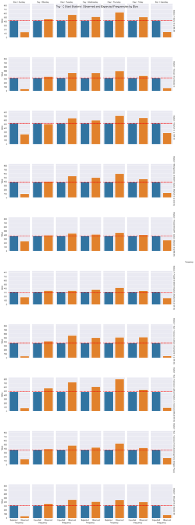

```python
#Plots the observed and expected frequencies of each station for each day
sns.set_style('darkgrid')
g = sns.catplot(freqSt,x='Frequency',y='Value', col='Day',row='Station',row_order=stations, hue='Frequency', kind='bar', margin_titles=True, height=4, aspect=.5);
g.fig.suptitle("Top 10 Start Stations' Observed and Expected Frequencies by Day", fontsize=15);

# Function to draw a horizontal line
def hline(*args, **kwargs):
    #Iterates through indexes to get the value of the Expected Frequency
    i=0
    for ax in g.axes.flat:
        ax.axhline(y=freqSt.loc[freqSt['Frequency']=='Expected', 'Value'].iloc[i], color='red', linestyle='--')
        i+=1
g.map(hline);
```

The chart highlights the disparity between observed and expected frequencies for each day at each of the top 10 start stations.

- Sunday and Saturday consistently see the least amount of rides compared to the weekdays for all involved stations.
- Sanfrancisco Caltrain Station 2 experiences a peak in rides on Tuesdays and Thursdays.

Action: Ford BikeShare can leverage this data by increasing bike availability at popular stations during weekdays to accomodate the rise in demand. They should adjust the distribution of bikes based on weekday demand patterns to ensure availability and manage demand. Additionally, they should schedule bike maintenance and repairs during the weekends to minimize disruption during the busy weekdays.

Ford should consider offering premium services for an additional fee during weekdays at popular stations. Premium services may include bikes with special features (built-in phone chargers, GPS) or bike reservations.

Overall, bike reservations should be offered during weekdays and peak hours at the top 10 start stations to boost revenue.

To Capstone Analysis